# PA1_template.Rmd

hhp94

6/6/2020

Loaded packages:  
1. “tidyverse”  
2. “xtable”  
3. “data.table”  
4. “lubridate”  
5. “gridExtra”

# I. Import:

## 1. Download the file

```r
url<-"https://d396qusza40orc.cloudfront.net/repdata%2Fdata%2Factivity.zip"
download.file(url, destfile = "./activity.zip", method = "curl")

activity<-read_csv("./activity.zip")
```

## 2. Summaries:

```r
summary(activity)
```

```
##      steps             date               interval
##  Min.   :  0.00   Min.   :2012-10-01   Min.   :   0.0
##  1st Qu.:  0.00   1st Qu.:2012-10-16   1st Qu.: 588.8
##  Median :  0.00   Median :2012-10-31   Median :1177.5
##  Mean   : 37.38   Mean   :2012-10-31   Mean   :1177.5
##  3rd Qu.: 12.00   3rd Qu.:2012-11-15   3rd Qu.:1766.2
##  Max.   :806.00   Max.   :2012-11-30   Max.   :2355.0
##  NA's   :2304
```

# II. Questions:

## 1. What is mean total number of steps taken per day?

### a. Calculate the total number of steps taken per day

We use dplyr and ggplot 2 to make the data frame and histogram.

```r
df_1<- activity %>% select(steps, date) %>%
        group_by(date = floor_date(date,"1 days")) %>%
        summarize(sum(steps, na.rm = TRUE))
```

```r
names(df_1)<-c("date","steps")

plot_1<-ggplot(df_1, aes(x=steps))+
        geom_histogram(binwidth=707, fill="#69b3a2", color="#e9ecef")+
        labs(x = "Number of steps/day with NA", y = "Frequency")+
        theme_bw()
```

Results:

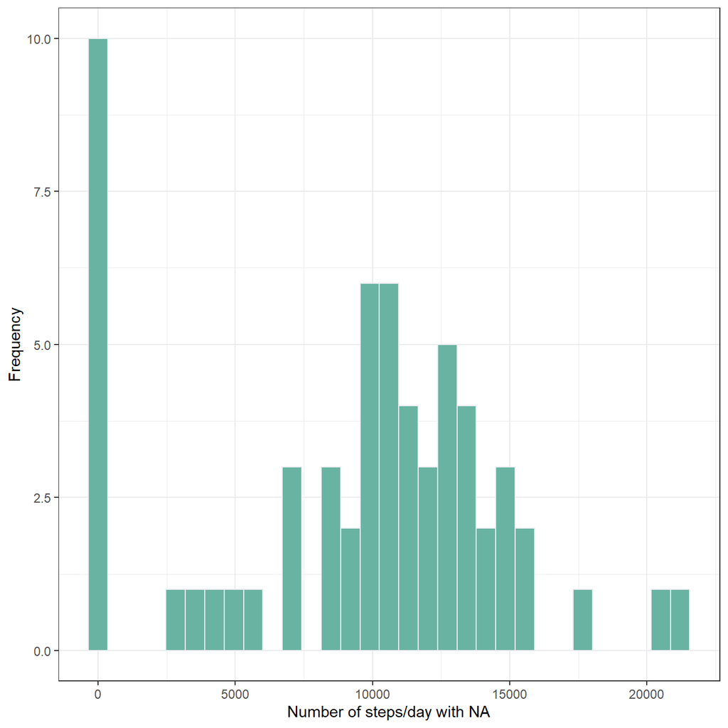

```r
plot_1
```

### b. Mean and median of total number of steps each day.

We create a new data frame in the form of a function.

```r
func_1<-function(x){
        df_2<- x %>%
                summarize("mean (steps)" = mean(x$steps))
        df_3<- x %>%
                summarize("median (steps)"= median(x$steps))
        df_4<- bind_cols(df_2,df_3)
        df_4
}
```

Results

```r
knitr::kable(func_1(df_1))
```

| mean (steps) | median (steps) |
| --- | --- |
| 9354.23 | 10395 |

## 2. What is the average daily activity pattern?

### a. Make a time series plot of the 5-minute interval and the average number of steps taken

Create a separate data frame using dplyr, and find the maximum

```r
df_2<- activity %>% select(steps, interval) %>%
        filter(!is.na(steps)) %>%
        group_by(interval) %>%
        summarize(mean(steps, na.rm = TRUE))
names(df_2)<-c("interval","steps")

max_int<- df_2 %>%
        filter(steps == max(steps))
max_int
```

```
## # A tibble: 1 x 2
##   interval steps
##      <dbl> <dbl>
## 1      835  206.
```

We then plot the data frame using ggplot2

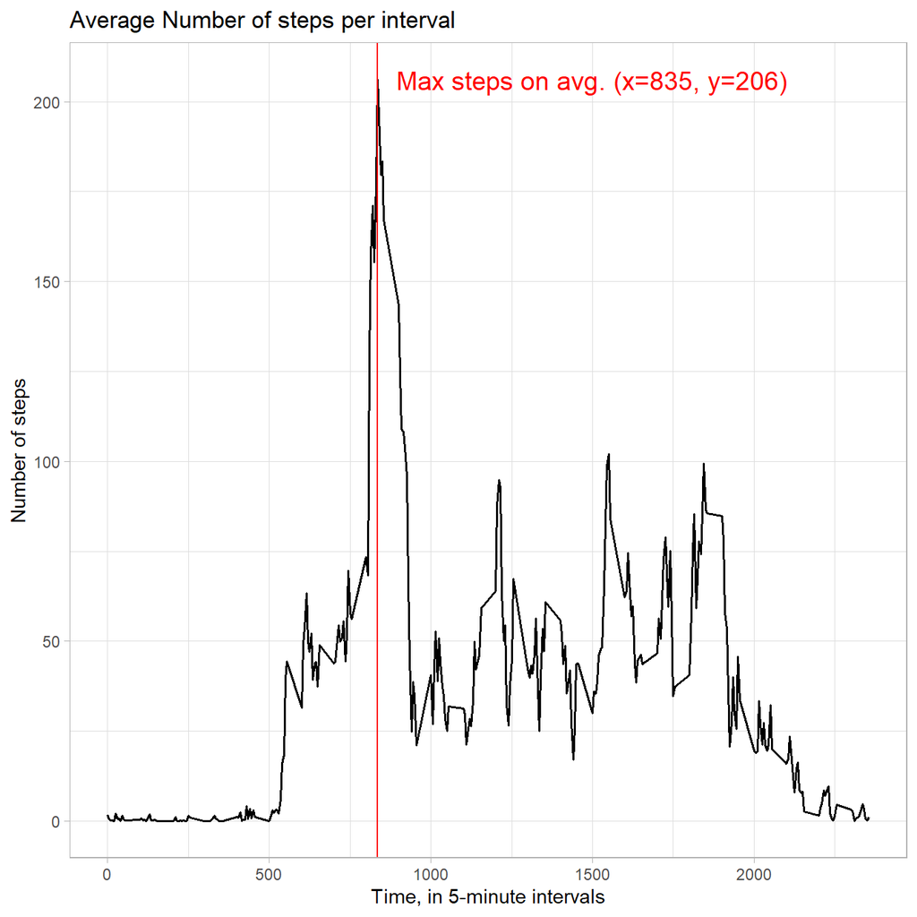

```r
plot_2<- ggplot(df_2, aes(interval,steps))+
        geom_line(size = 0.65)+
        labs(x = "Time, in 5-minute intervals", y = "Number of steps", title = "Average Number of steps per interval")+
        geom_vline(xintercept = max_int$interval, color = "red")+
        annotate("text", label = "Max steps on avg. (x=835, y=206)", x = 1500, y = 206, size = 5, colour = "red")+
        theme_light()
plot_2
```

### b. Which 5-minute interval, on average across all the days in the dataset, contains the max number of steps?

From the plot, we can see that the interval 835 minute has the highest avg number of steps at 206 steps

## 3. Imputing missing values

### a. What is total number of rows with NA?

From looking at the summary, we can see that there are 2304 rows with NAs.

### b. Decide on a strategy to fill the missing values in the dataset

I decided to use the mean for that 5-minute interval.

### c. Create the new dataset for the missing data to be filled in

The strategy for imputing NA is as follows:

```r
func_impute<-function(x){
        dat_filled <- left_join(activity, df_2, "interval")             #Left join the full data with the mean step by interval data
        processed<-sapply(x, function(y){                               #Sequentially, for any NA in the step column, replace that
                if(is.na(dat_filled[y,1])){                             #NA with the mean at that row's interval in a new column
                        dat_filled[y,1] <- dat_filled[y,4]
                        }
                else(dat_filled[y,1])
                })
        processed<-unname(processed)                                    #using sapply resulted in a list
        merged_vect<-sapply(processed, rbind)                           #row bind the list to make a full data frame
        new_tibble<- activity %>%
                select(-steps) %>%
                mutate(steps = merged_vect)                             #drop the old column with NA
}
merged_df<- func_impute(seq_along(activity$steps))
summary(merged_df)
```

```
##       date               interval          steps
##  Min.   :2012-10-01   Min.   :   0.0   Min.   :  0.00
##  1st Qu.:2012-10-16   1st Qu.: 588.8   1st Qu.:  0.00
##  Median :2012-10-31   Median :1177.5   Median :  0.00
##  Mean   :2012-10-31   Mean   :1177.5   Mean   : 37.38
##  3rd Qu.:2012-11-15   3rd Qu.:1766.2   3rd Qu.: 27.00
##  Max.   :2012-11-30   Max.   :2355.0   Max.   :806.00
```

We are good to go!

### d. Repeat part II. 1. for this new dataset

```r
df_3<- merged_df %>% select(steps, date) %>%
        group_by(date = floor_date(date,"1 days")) %>%
        summarize(sum(steps, na.rm = TRUE))
```

```r
names(df_3)<-c("date","steps")

plot_3<-ggplot(df_3, aes(x=steps))+
        geom_histogram(binwidth=707, fill="orange", color="red")+
        labs(x = "Number of steps/day with NA REMOVED", y = "Frequency")+
        theme_bw()
```

Results:

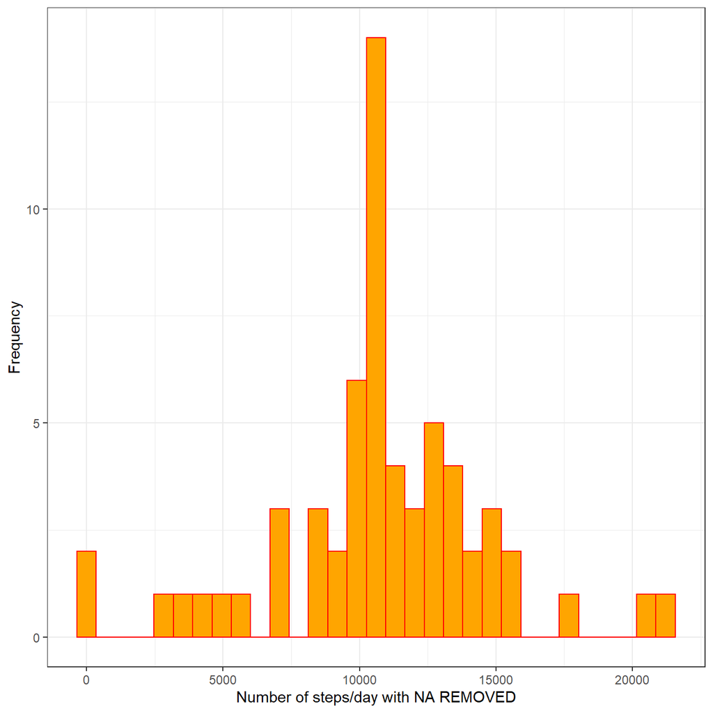

```r
plot_3
```

Then we check the mean and median:

```r
knitr::kable(func_1(df_3))
```

| mean (steps) | median (steps) |
| --- | --- |
| 10766.19 | 10766.19 |

## 4. Are there differences in activity patterns between weekdays and weekends?

### a. Create a new factor variable in the dataset with two levels - “weekday” and “weekend”

We can easily use dplyr to solve this problem

```r
merged_df_ft<- merged_df %>%
        mutate(date_ft = fct_collapse(as.factor(wday(merged_df$date)),weekday = c("2","3","4","5","6"), weekend = c("1","7"))) %>%
        group_by(interval, date_ft) %>%
        summarize(mean(steps, na.rm = TRUE))
```

```r
names(merged_df_ft)<-c("interval","date_ft","steps")
plot_4<- ggplot(merged_df_ft, aes(interval,steps))+
        geom_line(size = 0.65)+
        labs(x = "Time, in 5-minute intervals", y = "Number of steps", title = "Average Number of steps per interval")+
        facet_grid(merged_df_ft$date_ft~.)+
        theme_light()+
        theme(strip.text = element_text(colour = "red", size = 15))
```

We then plot the data frame using ggplot2

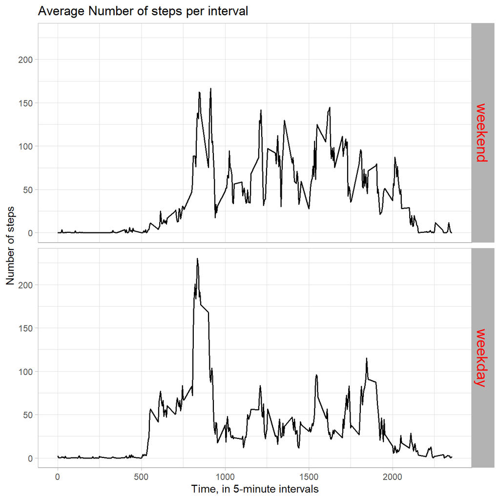

```r
plot_4
```

```r
png(file = "Histogram of Total Number of Steps_day.png", width = 640, height = 480)
plot_1
dev.off()
```

```r
write_csv(func_1(df_1),"Mean and Median of total steps each day.csv")

png(file = "Time series plot of average number of steps per interval.png", width = 640, height = 480)
plot_2
dev.off()
```

```r
png(file = "Histogram of Total Number of Steps per day WITHOUT NA.png", width = 640, height = 480)
plot_3
dev.off()
```

```r
write_csv(func_1(df_3), "Mean and Median of total steps each day NA REMOVED.csv")

png(file = "Time series plot of average number of steps per interval by weekday.png", width = 640, height = 480)
plot_4
dev.off()
```